# 浅野ゼミナール 夏合宿 2016

2016年度の夏合宿は昨年と同様、神奈川県の湘南国際村センターで9月9日〜9月11日の日程で行われました。

[figure not shown]

湘南国際村での集合写真

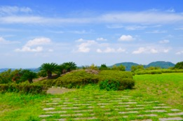

湘南国際村からの景色

ゼミ生の交流が中心である春合宿とは異なり、夏合宿では3・4年生による論文のリサーチ・デザインの発表と2年生によるビブリオバトルが行われました。リサーチ・デザインの発表では、グループごとに研究テーマと分析方法を発表し、他のゼミ生や先生から、今後、分析する上で建設的な意見をいただきました。発表されたテーマには「NHKの受信料を払わないのは誰か？」「候補者名と選挙結果」「自民党の派閥研究」「市議の報酬の決定要因」「選挙における学歴の重要性」「待機児童と得票率」などがありました。様々な意見を聞いていると、自分が思いもつかなかったような考え方や新たな視点を知ることができ、「そういう見方もできるのか」と、考えさせられました。別の角度から物事をみることの大切さと難しさを知りました。

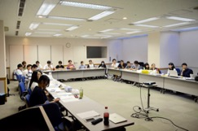

リサーチ・デザイン発表の様子

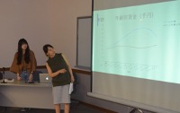

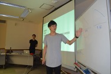

２年生10人によるビブリオバトルでは、伊坂幸太朗の『プリズム』や『グラスホッパー』、石川英輔の『大江戸神仙伝』など興味深い本が紹介されました。発表者の緊張がこちらにも伝わり、どの本も読んでみたいと思えるような発表ばかりでした。二人のビブリオウィナーを選ばれ、景品として図書券が送られました。

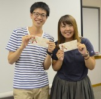

ビブリオウィナーの2人

ゼミ論文のリサーチデザイン発表とビブリオバトルが終了した2日目の夜に、全学年合同のビンゴ大会が行われました。今年の景品は数が多く、豪華商品も多々あり、ゼミ生の半数以上が景品を手に入れることができました。

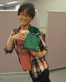

ビンゴ大会の様子

[figure not shown]

ビンゴ大会の様子

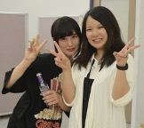

一息つくゼミ生たち

[figure not shown]

合宿に参加した学生全員、何か得るものがあった夏合宿だと思います。相談に乗ってくださった先輩方や、貴重な意見をくれた後輩たち、浅野先生。そして一緒に幹事の仕事を行った友人たちに感謝します。  
（文責：政経学部 法律政治学科 3年 工藤達勝）

### 参加した学生からの感想

#### 政経学部 法律政治学科 4年 板井恵里佳

今回の夏合宿は2年生から院生までが参加し、他のゼミにはない学びのある合宿となりました。3年生と４年生、院生は研究論文の中間発表がありました。学年を超えて意見を述べ、刺激し合えたので、それぞれが新しい課題を見つけることができました。浅野ゼミは3.4年生合同でゼミを行うので、年々ゼミのレベルが上がっているように感じます。 2年生はビブリオバトルで先輩や先生の前で時間制限のあるなか、発表を行うことはとても緊張したと思います。それぞれ個性があり、面白い発表でした。自分が２年生の時には、こんなにも上手にできただろうか、と考えてしまいました。 2年生3年生が執筆する来年の論文が楽しみである一方、卒業してしまうことを寂しくも感じます。残りの期間で満足のいく論文を執筆したいと思います。

#### 政経学部 法律政治学科 3年 小山雄規

今回、初めて参加した夏合宿は論文を書き上げていく上で、とても勉強になる合宿でした。リサーチ・デザインの発表を行い、浅野先生やゼミ生からコメントをいただいたことで、グループの課題が多く見つかりました。また、発表以外でもエニアグラムという性格診断を行い、自分が他人からどのように見られているかということを知ることができました。エニアグラムは就職活動や、人との交流でとても役にたつので学ぶことができて、よかったです。その他にも関わりの薄かったゼミ生たちとも親睦を深めることができ、とても貴重な時間を過ごすことができました。また、仲間たちの様々な素顔を知ることができました。この3日間でゼミ生の中が一層、深まったと思います。とても充実した３日間でした。

#### 政経学部 法律政治学科 2年 今田あゆみ

今回の夏合宿は、私にとって、とても得ることの多い合宿でした。まず初めに、3・4年生のリサーチ・デザインの発表の完成度の高さに驚かされました。私は2年に上がって「計量政治」を履修し、その手法や考え方を使って最終課題を書きました。しかし、同じ方法や考え方を使っていても、先輩方の発表はとても論理的でした。そして、もっと計量政治学や統計学を勉強してみたいと思いました。2つ目に面白かったのは2年生のビブリオバトルです。私の趣味は読書です。好きな本もたくさんあります。しかし、自分がなぜその本が好きなのか、本の魅力は何なのかを大勢の人に伝わるように話すことは、たいへん難しいものでした。また、仲の良い友達がオススメしている本はとても興味深く、何冊か読んでみようと思いました。初めての夏合宿でしたが、非常に有意義な時間を過ごせました。今回学んだことを無駄にせず、後期も頑張っていきたいと思います。